# Bivariate Analysis

## Ucitavanje potrebnih biblioteka

```r
library(tidyverse)
library(car)
library(FSA)
library(rstatix)
```

### Annual.Income prema Number.of.Dependents

Osnovni opis varijabli

```r
df_summary_feature <- train %>%
  group_by(Number.of.Dependents) %>%
  summarise(
    Count = n(),
    Mean_Annual.Income = mean(Annual.Income, na.rm = TRUE),
    Median_Annual.Income = median(Annual.Income, na.rm = TRUE),
    Std_Annual.Income = sd(Annual.Income, na.rm = TRUE),
    IQR_Annual.Income = IQR(Annual.Income, na.rm = TRUE)
  ) %>%
  arrange(desc(Mean_Annual.Income))

print(df_summary_feature)
```

| Number.of.Dependents | Count | Mean_Annual.Income | Median_Annual.Income | Std_Annual.Income | IQR_Annual.Income |
| --- | --- | --- | --- | --- | --- |
| NA | 109672 | 33502.15 | 24398.5 | 32744.37 | 37088 |
| 4 | 220340 | 32804.71 | 23981.0 | 32163.74 | 36597 |
| 3 | 221475 | 32687.48 | 23983.0 | 31999.93 | 36435 |
| 1 | 215076 | 32634.80 | 23783.0 | 32200.89 | 36636 |
| 2 | 215313 | 32626.18 | 23861.0 | 32147.54 | 36478 |
| 0 | 218124 | 32589.30 | 23840.0 | 32095.79 | 36528 |

Graficka reprezentacija varijabli

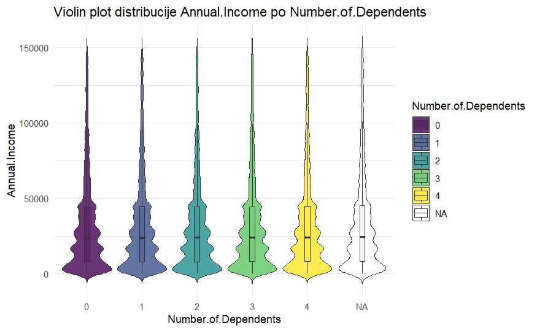

```r
ggplot(train, aes(x = Number.of.Dependents, y = Annual.Income, fill = Number.of.Dependents)) +
  geom_violin(trim = FALSE, alpha = 0.8) +
  geom_boxplot(width = 0.1, outlier.shape = NA, alpha = 0.3) +
  labs(title = "Violin plot distribucije Annual.Income po Number.of.Dependents", x = "Number.of.Dependents", y = "Annual.Income") +
  theme_minimal()
```

Statisticka analiza zavisnosti varijabli

```r
set.seed(123)
categories <- unique(train$Number.of.Dependents)
categories <- categories[!is.na(categories)]

shapiro_boot <- function(cat) {
  values <- na.omit(train$Annual.Income[train$Number.of.Dependents == cat])

  if (length(values) > 3) {
    p_values <- replicate(500, shapiro.test(sample(values, min(3000, length(values))))$p.value)
    p_mean <- mean(p_values)

    if (p_mean > 0.05) {
      sprintf("Varijabla Annual.Income po %s kategoriji ima normalnu raspodelu.", as.character(cat))
    } else {
      sprintf("Varijabla Annual.Income po %s kategoriji nema normalnu raspodelu.", as.character(cat))
    }
  }
  else {
    sprintf("Varijabla Annual.Income po %s kategoriji ima manje od 3 observacije.", as.character(cat))
  }
}

lapply(categories, shapiro_boot)
```

```
[[1]]
[1] "Varijabla Annual.Income po 1 kategoriji nema normalnu raspodelu."

[[2]]
[1] "Varijabla Annual.Income po 3 kategoriji nema normalnu raspodelu."

[[3]]
[1] "Varijabla Annual.Income po 2 kategoriji nema normalnu raspodelu."

[[4]]
[1] "Varijabla Annual.Income po 0 kategoriji nema normalnu raspodelu."

[[5]]
[1] "Varijabla Annual.Income po 4 kategoriji nema normalnu raspodelu."
```

Kruskal-Wallis test radi statisticke provere distribucije po kategorijama:

```r
p_value <- kruskal_test(Annual.Income ~ Number.of.Dependents, data = train)$p

if (p_value > 0.05) {
  print("Nema statisticke razlike izmedju distribucija Annual.Income po kategorijama Number.of.Dependents atributa.")
} else {
  print("Postoji statisticka razlika izmedju distribucija Annual.Income po kategorijama Number.of.Dependents atributa.")
}
```

```
[1] "Postoji statisticka razlika izmedju distribucija Annual.Income po kategorijama Number.of.Dependents atributa."
```

Racunamo efekat Kruskal-Wallis testa kako bismo proverili:

```r
kruskal_effsize(Annual.Income ~ Number.of.Dependents, data = train)$effsize
```

```
Kruskal-Wallis chi-squared
              9.035775e-06
```

Iako je Kruskal-Wallis test ukazao na to da postoji statisticki znacajna razlika u raspodeli Annual.Income varijable u odnosu na nivoe Number.of.Dependents varijable, analizom vrednosti efekta, utvrdjujemo da je ova razlika minimalna i prakticno neprimenljiva.

### Annual.Income prema Education.Level

Osnovni opis varijabli

```r
df_summary_feature <- train %>%
  group_by(Education.Level) %>%
  summarise(
    Count = n(),
    Mean_Annual.Income = mean(Annual.Income, na.rm = TRUE),
    Median_Annual.Income = median(Annual.Income, na.rm = TRUE),
    Std_Annual.Income = sd(Annual.Income, na.rm = TRUE),
    IQR_Annual.Income = IQR(Annual.Income, na.rm = TRUE)
  ) %>%
  arrange(desc(Mean_Annual.Income))

print(df_summary_feature)
```

| Education.Level | Count | Mean_Annual.Income | Median_Annual.Income | Std_Annual.Income | IQR_Annual.Income |
| --- | --- | --- | --- | --- | --- |
| High School | 289441 | 32884.98 | 23961 | 32351.28 | 36642 |
| Master's | 303818 | 32744.23 | 23952 | 32153.03 | 36579 |
| PhD | 303507 | 32714.71 | 23981 | 32100.16 | 36641 |
| Bachelor's | 303234 | 32643.41 | 23862 | 32120.66 | 36621 |

Graficka reprezentacija varijabli

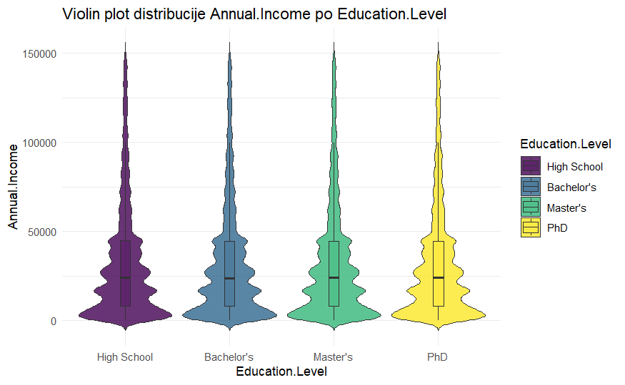

```r
ggplot(train, aes(x = Education.Level, y = Annual.Income, fill = Education.Level)) +
  geom_violin(trim = FALSE, alpha = 0.8) +
  geom_boxplot(width = 0.1, outlier.shape = NA, alpha = 0.3) +
  labs(title = "Violin plot distribucije Annual.Income po Education.Level", x = "Education.Level", y = "Annual.Income") +
  theme_minimal()
```

Statisticka analiza zavisnosti varijabli

```r
set.seed(123)
categories <- unique(train$Education.Level)
categories <- categories[!is.na(categories)]

shapiro_boot <- function(cat) {
  values <- na.omit(train$Annual.Income[train$Education.Level == cat])

  if (length(values) > 3) {
    p_values <- replicate(500, shapiro.test(sample(values, min(3000, length(values))))$p.value)
    p_mean <- mean(p_values)

    if (p_mean > 0.05) {
      sprintf("Varijabla Annual.Income po %s kategoriji ima normalnu raspodelu.", as.character(cat))
    } else {
      sprintf("Varijabla Annual.Income po %s kategoriji nema normalnu raspodelu.", as.character(cat))
    }
  }
  else {
    sprintf("Varijabla Annual.Income po %s kategoriji ima manje od 3 observacije.", as.character(cat))
  }
}

lapply(categories, shapiro_boot)
```

```
[[1]]
[1] "Varijabla Annual.Income po Bachelor's kategoriji nema normalnu raspodelu."

[[2]]
[1] "Varijabla Annual.Income po Master's kategoriji nema normalnu raspodelu."

[[3]]
[1] "Varijabla Annual.Income po High School kategoriji nema normalnu raspodelu."

[[4]]
[1] "Varijabla Annual.Income po PhD kategoriji nema normalnu raspodelu."
```

Kruskal-Wallis test radi statisticke provere distribucije po kategorijama:

```r
p_value <- kruskal_test(Annual.Income ~ Education.Level, data = train)$p

if (p_value > 0.05) {
  print("Nema statisticke razlike izmedju distribucija Annual.Income po kategorijama Education.Level atributa.")
} else {
  print("Postoji statisticka razlika izmedju distribucija Annual.Income po kategorijama Education.Level atributa.")
}
```

```
[1] "Nema statisticke razlike izmedju distribucija Annual.Income po kategorijama Education.Level atributa."
```

### Annual.Income prema Occupation

Osnovni opis varijabli

```r
df_summary_feature <- train %>%
  group_by(Occupation) %>%
  summarise(
    Count = n(),
    Mean_Annual.Income = mean(Annual.Income, na.rm = TRUE),
    Median_Annual.Income = median(Annual.Income, na.rm = TRUE),
    Std_Annual.Income = sd(Annual.Income, na.rm = TRUE),
    IQR_Annual.Income = IQR(Annual.Income, na.rm = TRUE)
  ) %>%
  arrange(desc(Mean_Annual.Income))

print(df_summary_feature)
```

| Occupation | Count | Mean_Annual.Income | Median_Annual.Income | Std_Annual.Income | IQR_Annual.Income |
| --- | --- | --- | --- | --- | --- |
| Self-Employed | 282645 | 32909.19 | 23961 | 32354.54 | 36771 |
| Unemployed | 276530 | 32864.54 | 23962 | 32337.41 | 36757 |
| Employed | 282750 | 32747.06 | 23961 | 32218.62 | 36660 |
| NA | 358075 | 32522.41 | 23890 | 31885.61 | 36157 |

Graficka reprezentacija varijabli

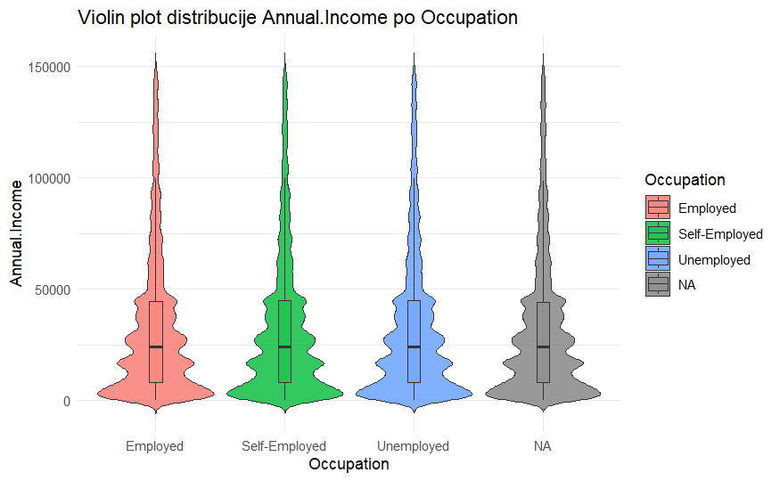

```r
ggplot(train, aes(x = Occupation, y = Annual.Income, fill = Occupation)) +
  geom_violin(trim = FALSE, alpha = 0.8) +
  geom_boxplot(width = 0.1, outlier.shape = NA, alpha = 0.3) +
  labs(title = "Violin plot distribucije Annual.Income po Occupation", x = "Occupation", y = "Annual.Income") +
  theme_minimal()
```

Statisticka analiza zavisnosti varijabli

```r
set.seed(123)
categories <- unique(train$Occupation)
categories <- categories[!is.na(categories)]

shapiro_boot <- function(cat) {
  values <- na.omit(train$Annual.Income[train$Occupation == cat])

  if (length(values) > 3) {
    p_values <- replicate(500, shapiro.test(sample(values, min(3000, length(values))))$p.value)
    p_mean <- mean(p_values)

    if (p_mean > 0.05) {
      sprintf("Varijabla Annual.Income po %s kategoriji ima normalnu raspodelu.", as.character(cat))
    } else {
      sprintf("Varijabla Annual.Income po %s kategoriji nema normalnu raspodelu.", as.character(cat))
    }
  }
  else {
    sprintf("Varijabla Annual.Income po %s kategoriji ima manje od 3 observacije.", as.character(cat))
  }
}

lapply(categories, shapiro_boot)
```

```
[[1]]
[1] "Varijabla Annual.Income po Self-Employed kategoriji nema normalnu raspodelu."

[[2]]
[1] "Varijabla Annual.Income po Employed kategoriji nema normalnu raspodelu."

[[3]]
[1] "Varijabla Annual.Income po Unemployed kategoriji nema normalnu raspodelu."
```

Kruskal-Wallis test radi statisticke provere distribucije po kategorijama:

```r
p_value <- kruskal_test(Annual.Income ~ Occupation, data = train)$p

if (p_value > 0.05) {
  print("Nema statisticke razlike izmedju distribucija Annual.Income po kategorijama Occupation atributa.")
} else {
  print("Postoji statisticka razlika izmedju distribucija Annual.Income po kategorijama Occupation atributa.")
}
```

```
[1] "Nema statisticke razlike izmedju distribucija Annual.Income po kategorijama Occupation atributa."
```

### Annual.Income prema Policy.Type

Osnovni opis varijabli

```r
df_summary_feature <- train %>%
  group_by(Policy.Type) %>%
  summarise(
    Count = n(),
    Mean_Annual.Income = mean(Annual.Income, na.rm = TRUE),
    Median_Annual.Income = median(Annual.Income, na.rm = TRUE),
    Std_Annual.Income = sd(Annual.Income, na.rm = TRUE),
    IQR_Annual.Income = IQR(Annual.Income, na.rm = TRUE)
  ) %>%
  arrange(desc(Mean_Annual.Income))

print(df_summary_feature)
```

| Policy.Type | Count | Mean_Annual.Income | Median_Annual.Income | Std_Annual.Income | IQR_Annual.Income |
| --- | --- | --- | --- | --- | --- |
| Basic | 398554 | 32800.72 | 23897 | 32260.46 | 36621 |
| Premium | 401846 | 32740.11 | 23981 | 32098.22 | 36581 |
| Comprehensive | 399600 | 32694.98 | 23891 | 32180.22 | 36636 |

Graficka reprezentacija varijabli

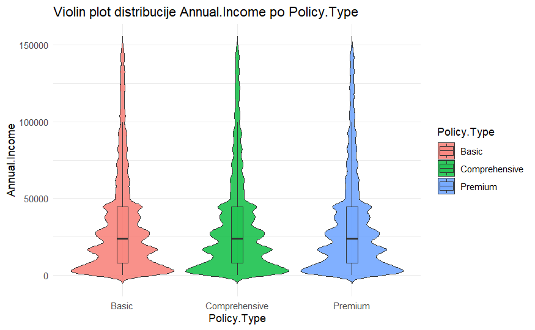

```r
ggplot(train, aes(x = Policy.Type, y = Annual.Income, fill = Policy.Type)) +
  geom_violin(trim = FALSE, alpha = 0.8) +
  geom_boxplot(width = 0.1, outlier.shape = NA, alpha = 0.3) +
  labs(title = "Violin plot distribucije Annual.Income po Policy.Type", x = "Policy.Type", y = "Annual.Income") +
  theme_minimal()
```

Statisticka analiza zavisnosti varijabli

```r
set.seed(123)
categories <- unique(train$Policy.Type)
categories <- categories[!is.na(categories)]

shapiro_boot <- function(cat) {
  values <- na.omit(train$Annual.Income[train$Policy.Type == cat])

  if (length(values) > 3) {
    p_values <- replicate(500, shapiro.test(sample(values, min(3000, length(values))))$p.value)
    p_mean <- mean(p_values)

    if (p_mean > 0.05) {
      sprintf("Varijabla Annual.Income po %s kategoriji ima normalnu raspodelu.", as.character(cat))
    } else {
      sprintf("Varijabla Annual.Income po %s kategoriji nema normalnu raspodelu.", as.character(cat))
    }
  }
  else {
    sprintf("Varijabla Annual.Income po %s kategoriji ima manje od 3 observacije.", as.character(cat))
  }
}

lapply(categories, shapiro_boot)
```

```
[[1]]
[1] "Varijabla Annual.Income po Premium kategoriji nema normalnu raspodelu."

[[2]]
[1] "Varijabla Annual.Income po Comprehensive kategoriji nema normalnu raspodelu."

[[3]]
[1] "Varijabla Annual.Income po Basic kategoriji nema normalnu raspodelu."
```

Kruskal-Wallis test radi statisticke provere distribucije po kategorijama:

```r
p_value <- kruskal_test(Annual.Income ~ Policy.Type, data = train)$p

if (p_value > 0.05) {
  print("Nema statisticke razlike izmedju distribucija Annual.Income po kategorijama Policy.Type atributa.")
} else {
  print("Postoji statisticka razlika izmedju distribucija Annual.Income po kategorijama Policy.Type atributa.")
}
```

```
[1] "Nema statisticke razlike izmedju distribucija Annual.Income po kategorijama Policy.Type atributa."
```

### Annual.Income prema Insurance.Duration

Osnovni opis varijabli

```r
df_summary_feature <- train %>%
  group_by(Insurance.Duration) %>%
  summarise(
    Count = n(),
    Mean_Annual.Income = mean(Annual.Income, na.rm = TRUE),
    Median_Annual.Income = median(Annual.Income, na.rm = TRUE),
    Std_Annual.Income = sd(Annual.Income, na.rm = TRUE),
    IQR_Annual.Income = IQR(Annual.Income, na.rm = TRUE)
  ) %>%
  arrange(desc(Mean_Annual.Income))

print(df_summary_feature)
```

| Insurance.Duration | Count | Mean_Annual.Income | Median_Annual.Income | Std_Annual.Income | IQR_Annual.Income |
| --- | --- | --- | --- | --- | --- |
| 4 | 132182 | 32860.96 | 23961 | 32306.37 | 36708.0 |
| 6 | 132141 | 32841.30 | 23981 | 32327.02 | 36676.0 |
| 3 | 132018 | 32808.47 | 23892 | 32235.41 | 36664.0 |
| 8 | 133800 | 32803.18 | 23982 | 32186.93 | 36579.0 |
| 5 | 132253 | 32763.19 | 23965 | 32275.63 | 36654.0 |
| 9 | 137781 | 32697.47 | 23891 | 32110.32 | 36539.0 |
| 1 | 135072 | 32677.81 | 23981 | 31942.52 | 36621.0 |
| 7 | 133592 | 32642.74 | 23891 | 32184.55 | 36427.5 |
| 2 | 131160 | 32614.69 | 23784 | 32051.76 | 36527.5 |
| NA | 1 | 30206.00 | 30206 | NA | 0.0 |

Graficka reprezentacija varijabli

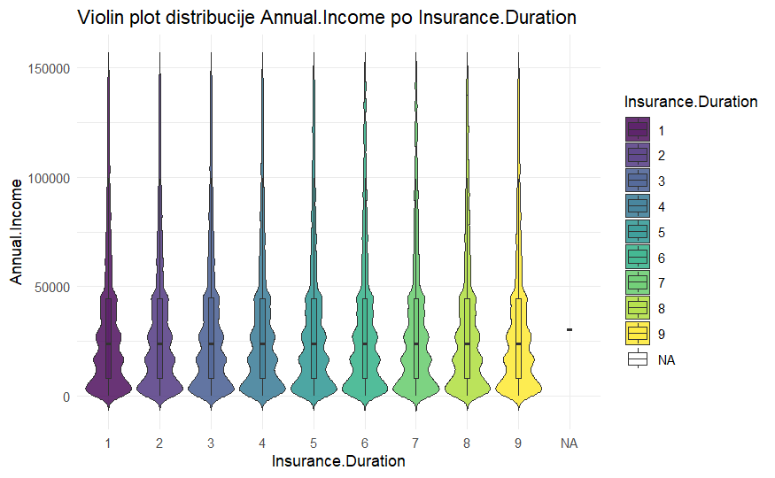

```r
ggplot(train, aes(x = Insurance.Duration, y = Annual.Income, fill = Insurance.Duration)) +
  geom_violin(trim = FALSE, alpha = 0.8) +
  geom_boxplot(width = 0.1, outlier.shape = NA, alpha = 0.3) +
  labs(title = "Violin plot distribucije Annual.Income po Insurance.Duration", x = "Insurance.Duration", y = "Annual.Income") +
  theme_minimal()
```

Statisticka analiza zavisnosti varijabli

```r
set.seed(123)
categories <- unique(train$Insurance.Duration)
categories <- categories[!is.na(categories)]

shapiro_boot <- function(cat) {
  values <- na.omit(train$Annual.Income[train$Insurance.Duration == cat])

  if (length(values) > 3) {
    p_values <- replicate(500, shapiro.test(sample(values, min(3000, length(values))))$p.value)
    p_mean <- mean(p_values)

    if (p_mean > 0.05) {
      sprintf("Varijabla Annual.Income po %s kategoriji ima normalnu raspodelu.", as.character(cat))
    } else {
      sprintf("Varijabla Annual.Income po %s kategoriji nema normalnu raspodelu.", as.character(cat))
    }
  }
  else {
    sprintf("Varijabla Annual.Income po %s kategoriji ima manje od 3 observacije.", as.character(cat))
  }
}

lapply(categories, shapiro_boot)
```

```
[[1]]
[1] "Varijabla Annual.Income po 5 kategoriji nema normalnu raspodelu."

[[2]]
[1] "Varijabla Annual.Income po 2 kategoriji nema normalnu raspodelu."

[[3]]
[1] "Varijabla Annual.Income po 3 kategoriji nema normalnu raspodelu."

[[4]]
[1] "Varijabla Annual.Income po 1 kategoriji nema normalnu raspodelu."

[[5]]
[1] "Varijabla Annual.Income po 4 kategoriji nema normalnu raspodelu."

[[6]]
[1] "Varijabla Annual.Income po 6 kategoriji nema normalnu raspodelu."

[[7]]
[1] "Varijabla Annual.Income po 8 kategoriji nema normalnu raspodelu."

[[8]]
[1] "Varijabla Annual.Income po 9 kategoriji nema normalnu raspodelu."

[[9]]
[1] "Varijabla Annual.Income po 7 kategoriji nema normalnu raspodelu."
```

Kruskal-Wallis test radi statisticke provere distribucije po kategorijama:

```r
p_value <- kruskal_test(Annual.Income ~ Insurance.Duration, data = train)$p

if (p_value > 0.05) {
  print("Nema statisticke razlike izmedju distribucija Annual.Income po kategorijama Insurance.Duration atributa.")
} else {
  print("Postoji statisticka razlika izmedju distribucija Annual.Income po kategorijama Insurance.Duration atributa.")
}
```

```
[1] "Nema statisticke razlike izmedju distribucija Annual.Income po kategorijama Insurance.Duration atributa."
```

### Annual.Income prema Previous.Claims

Posto su grupe koje imaju 7-9 zahteva veoma male, grupisacemo ih u jednu kategoriju “7+” radi testiranja.

```r
train$PreviousClaimsGrouped <- as.character(train$Previous.Claims)
train$PreviousClaimsGrouped[train$PreviousClaimsGrouped %in% c("7","8","9")] <- "7+"
train$PreviousClaimsGrouped <- factor(train$PreviousClaimsGrouped,
                                      levels = c("0","1","2","3","4","5","6","7+"))

table(train$PreviousClaimsGrouped, useNA="ifany")
```

```
     0      1      2      3      4      5      6     7+   <NA>
305433 300811 167661  49011  10668   2018    302     67 364029
```

Osnovni opis varijabli

```r
df_summary_feature <- train %>%
  group_by(PreviousClaimsGrouped) %>%
  summarise(
    Count = n(),
    Mean_Annual.Income = mean(Annual.Income, na.rm = TRUE),
    Median_Annual.Income = median(Annual.Income, na.rm = TRUE),
    Std_Annual.Income = sd(Annual.Income, na.rm = TRUE),
    IQR_Annual.Income = IQR(Annual.Income, na.rm = TRUE)
  )

print(df_summary_feature)
```

| PreviousClaimsGrouped | Count | Mean_Annual.Income | Median_Annual.Income | Std_Annual.Income | IQR_Annual.Income |
| --- | --- | --- | --- | --- | --- |
| 0 | 305433 | 32219.03 | 23893 | 31255.15 | 34979.00 |
| 1 | 300811 | 32102.20 | 23862 | 31234.01 | 35072.00 |
| 2 | 167661 | 34590.01 | 23648 | 35638.13 | 47044.50 |
| 3 | 49011 | 37455.47 | 26062 | 36925.16 | 52067.50 |
| 4 | 10668 | 38149.10 | 26343 | 37543.27 | 53652.50 |
| 5 | 2018 | 38168.04 | 26590 | 37246.20 | 52274.75 |
| 6 | 302 | 39917.17 | 28409 | 39757.57 | 54037.00 |
| 7+ | 67 | 39071.69 | 29934 | 36237.19 | 49048.00 |
| NA | 364029 | 32056.34 | 23863 | 31042.25 | 34957.00 |

Graficka reprezentacija varijabli

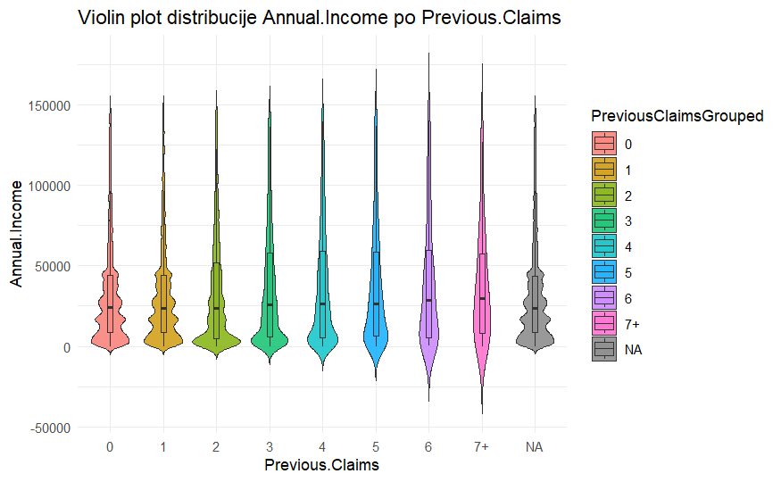

```r
ggplot(train, aes(x = PreviousClaimsGrouped, y = Annual.Income, fill = PreviousClaimsGrouped)) +
  geom_violin(trim = FALSE, alpha = 0.8) +
  geom_boxplot(width = 0.1, outlier.shape = NA, alpha = 0.3) +
  labs(title = "Violin plot distribucije Annual.Income po Previous.Claims", x = "Previous.Claims", y = "Annual.Income") +
  theme_minimal()
```

Statisticka analiza zavisnosti varijabli

```r
set.seed(123)
categories <- unique(train$PreviousClaimsGrouped)
categories <- categories[!is.na(categories)]

shapiro_boot <- function(cat) {
  values <- na.omit(train$Annual.Income[train$PreviousClaimsGrouped == cat])

  if (length(values) > 3) {
    p_values <- replicate(500, shapiro.test(sample(values, min(3000, length(values))))$p.value)
    p_mean <- mean(p_values)

    if (p_mean > 0.05) {
      sprintf("Varijabla Annual.Income po %s kategoriji ima normalnu raspodelu.", as.character(cat))
    } else {
      sprintf("Varijabla Annual.Income po %s kategoriji nema normalnu raspodelu.", as.character(cat))
    }
  }
  else {
    sprintf("Varijabla Annual.Income po %s kategoriji ima manje od 3 observacije.", as.character(cat))
  }
}

lapply(categories, shapiro_boot)
```

```
[[1]]
[1] "Varijabla Annual.Income po 2 kategoriji nema normalnu raspodelu."

[[2]]
[1] "Varijabla Annual.Income po 1 kategoriji nema normalnu raspodelu."

[[3]]
[1] "Varijabla Annual.Income po 0 kategoriji nema normalnu raspodelu."

[[4]]
[1] "Varijabla Annual.Income po 3 kategoriji nema normalnu raspodelu."

[[5]]
[1] "Varijabla Annual.Income po 4 kategoriji nema normalnu raspodelu."

[[6]]
[1] "Varijabla Annual.Income po 5 kategoriji nema normalnu raspodelu."

[[7]]
[1] "Varijabla Annual.Income po 6 kategoriji nema normalnu raspodelu."

[[8]]
[1] "Varijabla Annual.Income po 7+ kategoriji nema normalnu raspodelu."
```

Kruskal-Wallis test radi statisticke provere distribucije po kategorijama:

```r
p_value <- kruskal_test(Annual.Income ~ PreviousClaimsGrouped, data = train)$p

if (p_value > 0.05) {
  print("Nema statisticke razlike izmedju distribucija Annual.Income po kategorijama PreviousClaimsGrouped atributa.")
} else {
  print("Postoji statisticka razlika izmedju distribucija Annual.Income po kategorijama PreviousClaimsGrouped atributa.")
}
```

```
[1] "Postoji statisticka razlika izmedju distribucija Annual.Income po kategorijama PreviousClaimsGrouped atributa."
```

Racunamo efekat Kruskal-Wallis testa kako bismo proverili:

```r
kruskal_effsize(Annual.Income ~ PreviousClaimsGrouped, data = train)$effsize
```

```
Kruskal-Wallis chi-squared
              0.0003043139
```

Odbacujemo kolonu PreviousClaimsGrouped

```r
train <- train %>%
  select(-PreviousClaimsGrouped)
```

Kruskal-Wallis test ukazuje na to da postoji statisticki znacajna razlika u raspodeli Annual.Income varijable u odnosu na nivoe PreviousClaimsGrouped varijable, sto se moze potvrditi i analizom medijana i IQR-a: veci broj zahteva ukazuje na vece godisnje prihode. Effect size vrednost je mala, ali u poredjenju sa ostalim vrednostima, ovu vezu mozemo da smatramo znacajnom.

### Annual.Income prema Exercise.Frequency

Osnovni opis varijabli

```r
df_summary_feature <- train %>%
  group_by(Exercise.Frequency) %>%
  summarise(
    Count = n(),
    Mean_Annual.Income = mean(Annual.Income, na.rm = TRUE),
    Median_Annual.Income = median(Annual.Income, na.rm = TRUE),
    Std_Annual.Income = sd(Annual.Income, na.rm = TRUE),
    IQR_Annual.Income = IQR(Annual.Income, na.rm = TRUE)
  ) %>%
  arrange(desc(Mean_Annual.Income))

print(df_summary_feature)
```

| Exercise.Frequency | Count | Mean_Annual.Income | Median_Annual.Income | Std_Annual.Income | IQR_Annual.Income |
| --- | --- | --- | --- | --- | --- |
| Rarely | 299420 | 32865.12 | 23983 | 32258.41 | 36646.5 |
| Monthly | 299830 | 32797.17 | 23963 | 32218.67 | 36593.0 |
| Weekly | 306179 | 32715.52 | 23897 | 32103.34 | 36552.0 |
| Daily | 294571 | 32601.11 | 23861 | 32137.83 | 36713.0 |

Graficka reprezentacija varijabli

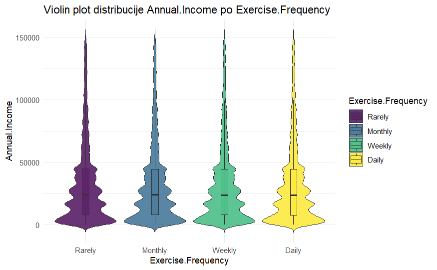

```r
ggplot(train, aes(x = Exercise.Frequency, y = Annual.Income, fill = Exercise.Frequency)) +
  geom_violin(trim = FALSE, alpha = 0.8) +
  geom_boxplot(width = 0.1, outlier.shape = NA, alpha = 0.3) +
  labs(title = "Violin plot distribucije Annual.Income po Exercise.Frequency", x = "Exercise.Frequency", y = "Annual.Income") +
  theme_minimal()
```

Statisticka analiza zavisnosti varijabli

```r
set.seed(123)
categories <- unique(train$Exercise.Frequency)
categories <- categories[!is.na(categories)]

shapiro_boot <- function(cat) {
  values <- na.omit(train$Annual.Income[train$Exercise.Frequency == cat])

  if (length(values) > 3) {
    p_values <- replicate(500, shapiro.test(sample(values, min(3000, length(values))))$p.value)
    p_mean <- mean(p_values)

    if (p_mean > 0.05) {
      sprintf("Varijabla Annual.Income po %s kategoriji ima normalnu raspodelu.", as.character(cat))
    } else {
      sprintf("Varijabla Annual.Income po %s kategoriji nema normalnu raspodelu.", as.character(cat))
    }
  }
  else {
    sprintf("Varijabla Annual.Income po %s kategoriji ima manje od 3 observacije.", as.character(cat))
  }
}

lapply(categories, shapiro_boot)
```

```
[[1]]
[1] "Varijabla Annual.Income po Weekly kategoriji nema normalnu raspodelu."

[[2]]
[1] "Varijabla Annual.Income po Monthly kategoriji nema normalnu raspodelu."

[[3]]
[1] "Varijabla Annual.Income po Daily kategoriji nema normalnu raspodelu."

[[4]]
[1] "Varijabla Annual.Income po Rarely kategoriji nema normalnu raspodelu."
```

Kruskal-Wallis test radi statisticke provere distribucije po kategorijama:

```r
p_value <- kruskal_test(Annual.Income ~ Exercise.Frequency, data = train)$p

if (p_value > 0.05) {
  print("Nema statisticke razlike izmedju distribucija Annual.Income po kategorijama Exercise.Frequency atributa.")
} else {
  print("Postoji statisticka razlika izmedju distribucija Annual.Income po kategorijama Exercise.Frequency atributa.")
}
```

```
[1] "Postoji statisticka razlika izmedju distribucija Annual.Income po kategorijama Exercise.Frequency atributa."
```

Racunamo efekat Kruskal-Wallis testa kako bismo proverili:

```r
kruskal_effsize(Annual.Income ~ Exercise.Frequency, data = train)$effsize
```

```
Kruskal-Wallis chi-squared
              1.036074e-05
```

Iako je Kruskal-Wallis test ukazao na to da postoji statisticki znacajna razlika u raspodeli Annual.Income varijable u odnosu na nivoe Exercise.Frequency varijable, analizom efekta testa, kao i uporedjivanjem medijana i IQR-a, utvrdjujemo da je ova razlika minimalna i prakticno neprimenljiva.

### Credit.Score prema Occupation

Osnovni opis varijabli

```r
df_summary_feature <- train %>%
  group_by(Occupation) %>%
  summarise(
    Count = n(),
    Mean_Credit.Score = mean(Credit.Score, na.rm = TRUE),
    Median_Credit.Score = median(Credit.Score, na.rm = TRUE),
    Std_Credit.Score = sd(Credit.Score, na.rm = TRUE),
    IQR_Credit.Score = IQR(Credit.Score, na.rm = TRUE)
  ) %>%
  arrange(desc(Mean_Credit.Score))

print(df_summary_feature)
```

| Occupation | Count | Mean_Credit.Score | Median_Credit.Score | Std_Credit.Score | IQR_Credit.Score |
| --- | --- | --- | --- | --- | --- |
| NA | 358075 | 594.6424 | 598 | 149.6330 | 252 |
| Employed | 282750 | 592.4463 | 595 | 149.9148 | 252 |
| Unemployed | 276530 | 592.0686 | 594 | 150.1453 | 252 |
| Self-Employed | 282645 | 592.0603 | 594 | 150.3134 | 254 |

Graficka reprezentacija varijabli

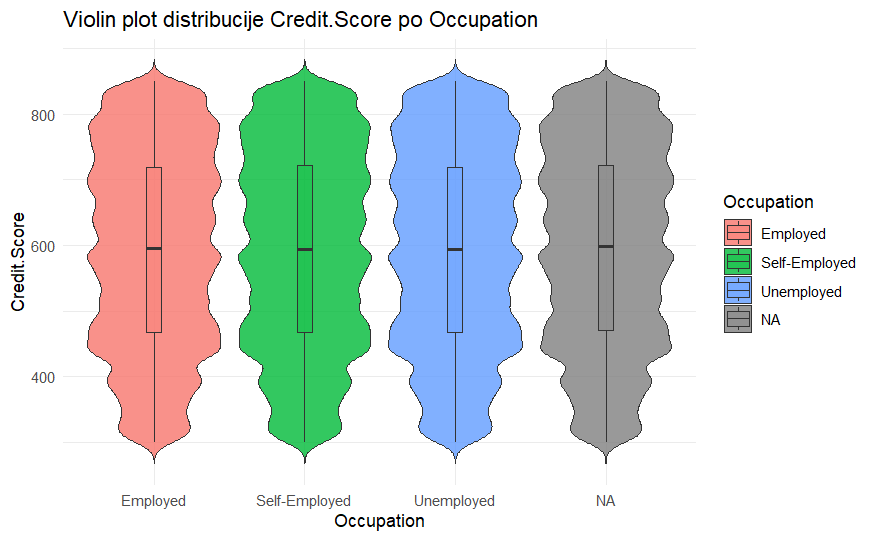

```r
ggplot(train, aes(x = Occupation, y = Credit.Score, fill = Occupation)) +
  geom_violin(trim = FALSE, alpha = 0.8) +
  geom_boxplot(width = 0.1, outlier.shape = NA, alpha = 0.3) +
  labs(title = "Violin plot distribucije Credit.Score po Occupation", x = "Occupation", y = "Credit.Score") +
  theme_minimal()
```

Statisticka analiza zavisnosti varijabli

```r
set.seed(123)
categories <- unique(train$Occupation)
categories <- categories[!is.na(categories)]

shapiro_boot <- function(cat) {
  values <- na.omit(train$Credit.Score[train$Occupation == cat])

  if (length(values) > 3) {
    p_values <- replicate(500, shapiro.test(sample(values, min(3000, length(values))))$p.value)
    p_mean <- mean(p_values)

    if (p_mean > 0.05) {
      sprintf("Varijabla Credit.Score po %s kategoriji ima normalnu raspodelu.", as.character(cat))
    } else {
      sprintf("Varijabla Credit.Score po %s kategoriji nema normalnu raspodelu.", as.character(cat))
    }
  }
  else {
    sprintf("Varijabla Credit.Score po %s kategoriji ima manje od 3 observacije.", as.character(cat))
  }
}

lapply(categories, shapiro_boot)
```

```
[[1]]
[1] "Varijabla Credit.Score po Self-Employed kategoriji nema normalnu raspodelu."

[[2]]
[1] "Varijabla Credit.Score po Employed kategoriji nema normalnu raspodelu."

[[3]]
[1] "Varijabla Credit.Score po Unemployed kategoriji nema normalnu raspodelu."
```

Kruskal-Wallis test radi statisticke provere distribucije po kategorijama:

```r
p_value <- kruskal_test(Credit.Score ~ Occupation, data = train)$p

if (p_value > 0.05) {
  print("Nema statisticke razlike izmedju distribucija Credit.Score po kategorijama Occupation atributa.")
} else {
  print("Postoji statisticka razlika izmedju distribucija Credit.Score po kategorijama Occupation atributa.")
}
```

```
[1] "Nema statisticke razlike izmedju distribucija Credit.Score po kategorijama Occupation atributa."
```

### Credit.Score prema Marital.Status

Osnovni opis varijabli

```r
df_summary_feature <- train %>%
  group_by(Marital.Status) %>%
  summarise(
    Count = n(),
    Mean_Credit.Score = mean(Credit.Score, na.rm = TRUE),
    Median_Credit.Score = median(Credit.Score, na.rm = TRUE),
    Std_Credit.Score = sd(Credit.Score, na.rm = TRUE),
    IQR_Credit.Score = IQR(Credit.Score, na.rm = TRUE)
  ) %>%
  arrange(desc(Mean_Credit.Score))

print(df_summary_feature)
```

| Marital.Status | Count | Mean_Credit.Score | Median_Credit.Score | Std_Credit.Score | IQR_Credit.Score |
| --- | --- | --- | --- | --- | --- |
| NA | 18529 | 599.4662 | 600 | 148.3849 | 247 |
| Divorced | 391764 | 593.4823 | 596 | 149.7171 | 252 |
| Married | 394316 | 592.9243 | 595 | 150.1460 | 253 |
| Single | 395391 | 592.0674 | 595 | 150.1448 | 252 |

Graficka reprezentacija varijabli

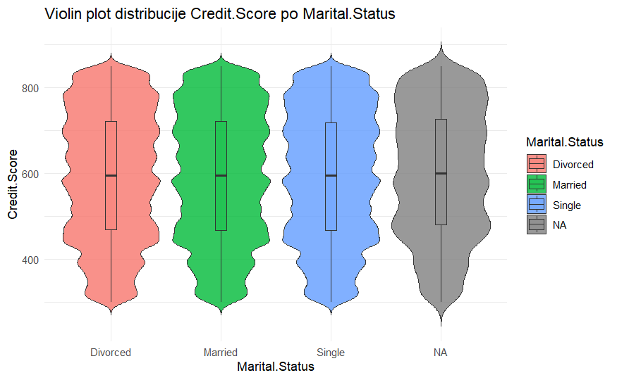

```r
ggplot(train, aes(x = Marital.Status, y = Credit.Score, fill = Marital.Status)) +
  geom_violin(trim = FALSE, alpha = 0.8) +
  geom_boxplot(width = 0.1, outlier.shape = NA, alpha = 0.3) +
  labs(title = "Violin plot distribucije Credit.Score po Marital.Status", x = "Marital.Status", y = "Credit.Score") +
  theme_minimal()
```

Statisticka analiza zavisnosti varijabli

```r
set.seed(123)
categories <- unique(train$Marital.Status)
categories <- categories[!is.na(categories)]

shapiro_boot <- function(cat) {
  values <- na.omit(train$Credit.Score[train$Marital.Status == cat])

  if (length(values) > 3) {
    p_values <- replicate(500, shapiro.test(sample(values, min(3000, length(values))))$p.value)
    p_mean <- mean(p_values)

    if (p_mean > 0.05) {
      sprintf("Varijabla Credit.Score po %s kategoriji ima normalnu raspodelu.", as.character(cat))
    } else {
      sprintf("Varijabla Credit.Score po %s kategoriji nema normalnu raspodelu.", as.character(cat))
    }
  }
  else {
    sprintf("Varijabla Credit.Score po %s kategoriji ima manje od 3 observacije.", as.character(cat))
  }
}

lapply(categories, shapiro_boot)
```

```
[[1]]
[1] "Varijabla Credit.Score po Married kategoriji nema normalnu raspodelu."

[[2]]
[1] "Varijabla Credit.Score po Divorced kategoriji nema normalnu raspodelu."

[[3]]
[1] "Varijabla Credit.Score po Single kategoriji nema normalnu raspodelu."
```

Kruskal-Wallis test radi statisticke provere distribucije po kategorijama:

```r
p_value <- kruskal_test(Credit.Score ~ Marital.Status, data = train)$p

if (p_value > 0.05) {
  print("Nema statisticke razlike izmedju distribucija Credit.Score po kategorijama Marital.Status atributa.")
} else {
  print("Postoji statisticka razlika izmedju distribucija Credit.Score po kategorijama Marital.Status atributa.")
}
```

```
[1] "Postoji statisticka razlika izmedju distribucija Credit.Score po kategorijama Marital.Status atributa."
```

Racunamo efekat Kruskal-Wallis testa kako bismo proverili:

```r
kruskal_effsize(Credit.Score ~ Marital.Status, data = train)$effsize
```

```
Kruskal-Wallis chi-squared
              1.082398e-05
```

Iako je Kruskal-Wallis test ukazao na to da postoji statisticki znacajna razlika u raspodeli Credit.Score varijable u odnosu na nivoe Marital.Status varijable, analizom vrednosti efekta, kao i uporedjivanjem medijana i IQR-a, utvrdjujemo da je ova razlika minimalna i prakticno neprimenljiva.

### Credit.Score prema Number.of.Dependents

Osnovni opis varijabli

```r
df_summary_feature <- train %>%
  group_by(Number.of.Dependents) %>%
  summarise(
    Count = n(),
    Mean_Credit.Score = mean(Credit.Score, na.rm = TRUE),
    Median_Credit.Score = median(Credit.Score, na.rm = TRUE),
    Std_Credit.Score = sd(Credit.Score, na.rm = TRUE),
    IQR_Credit.Score = IQR(Credit.Score, na.rm = TRUE)
  ) %>%
  arrange(desc(Mean_Credit.Score))

print(df_summary_feature)
```

| Number.of.Dependents | Count | Mean_Credit.Score | Median_Credit.Score | Std_Credit.Score | IQR_Credit.Score |
| --- | --- | --- | --- | --- | --- |
| 2 | 215313 | 594.3198 | 597 | 149.6895 | 252 |
| 1 | 215076 | 593.6139 | 597 | 149.4442 | 251 |
| 0 | 218124 | 593.1464 | 595 | 149.8101 | 252 |
| 3 | 221475 | 592.9403 | 595 | 150.1594 | 253 |
| 4 | 220340 | 592.5826 | 595 | 150.0805 | 252 |
| NA | 109672 | 589.0475 | 590 | 151.3233 | 255 |

Graficka reprezentacija varijabli

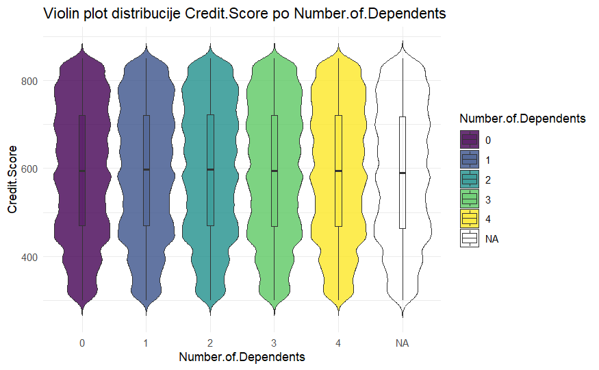

```r
ggplot(train, aes(x = Number.of.Dependents, y = Credit.Score, fill = Number.of.Dependents)) +
  geom_violin(trim = FALSE, alpha = 0.8) +
  geom_boxplot(width = 0.1, outlier.shape = NA, alpha = 0.3) +
  labs(title = "Violin plot distribucije Credit.Score po Number.of.Dependents", x = "Number.of.Dependents", y = "Credit.Score") +
  theme_minimal()
```

Statisticka analiza zavisnosti varijabli

```r
set.seed(123)
categories <- unique(train$Number.of.Dependents)
categories <- categories[!is.na(categories)]

shapiro_boot <- function(cat) {
  values <- na.omit(train$Credit.Score[train$Number.of.Dependents == cat])

  if (length(values) > 3) {
    p_values <- replicate(500, shapiro.test(sample(values, min(3000, length(values))))$p.value)
    p_mean <- mean(p_values)

    if (p_mean > 0.05) {
      sprintf("Varijabla Credit.Score po %s kategoriji ima normalnu raspodelu.", as.character(cat))
    } else {
      sprintf("Varijabla Credit.Score po %s kategoriji nema normalnu raspodelu.", as.character(cat))
    }
  }
  else {
    sprintf("Varijabla Credit.Score po %s kategoriji ima manje od 3 observacije.", as.character(cat))
  }
}

lapply(categories, shapiro_boot)
```

```
[[1]]
[1] "Varijabla Credit.Score po 1 kategoriji nema normalnu raspodelu."

[[2]]
[1] "Varijabla Credit.Score po 3 kategoriji nema normalnu raspodelu."

[[3]]
[1] "Varijabla Credit.Score po 2 kategoriji nema normalnu raspodelu."

[[4]]
[1] "Varijabla Credit.Score po 0 kategoriji nema normalnu raspodelu."

[[5]]
[1] "Varijabla Credit.Score po 4 kategoriji nema normalnu raspodelu."
```

Kruskal-Wallis test radi statisticke provere distribucije po kategorijama:

```r
p_value <- kruskal_test(Credit.Score ~ Number.of.Dependents, data = train)$p

if (p_value > 0.05) {
  print("Nema statisticke razlike izmedju distribucija Credit.Score po kategorijama Number.of.Dependents atributa.")
} else {
  print("Postoji statisticka razlika izmedju distribucija Credit.Score po kategorijama Number.of.Dependents atributa.")
}
```

```
[1] "Postoji statisticka razlika izmedju distribucija Credit.Score po kategorijama Number.of.Dependents atributa."
```

Racunamo efekat Kruskal-Wallis testa kako bismo proverili:

```r
kruskal_effsize(Credit.Score ~ Number.of.Dependents, data = train)$effsize
```

```
Kruskal-Wallis chi-squared
               9.05501e-06
```

Iako je Kruskal-Wallis test ukazao na to da postoji statisticki znacajna razlika u raspodeli Credit.Score varijable u odnosu na nivoe Number.of.Dependents varijable, analizom efekta testa, kao i uporedjivanjem medijana i IQR-a, utvrdjujemo da je ova razlika minimalna i prakticno neprimenljiva.

### Credit.Score prema Education.Level

Osnovni opis varijabli

```r
df_summary_feature <- train %>%
  group_by(Education.Level) %>%
  summarise(
    Count = n(),
    Mean_Credit.Score = mean(Credit.Score, na.rm = TRUE),
    Median_Credit.Score = median(Credit.Score, na.rm = TRUE),
    Std_Credit.Score = sd(Credit.Score, na.rm = TRUE),
    IQR_Credit.Score = IQR(Credit.Score, na.rm = TRUE)
  ) %>%
  arrange(desc(Mean_Credit.Score))

print(df_summary_feature)
```

| Education.Level | Count | Mean_Credit.Score | Median_Credit.Score | Std_Credit.Score | IQR_Credit.Score |
| --- | --- | --- | --- | --- | --- |
| Bachelor's | 303234 | 593.9143 | 596 | 149.8863 | 253 |
| PhD | 303507 | 592.9467 | 595 | 150.0407 | 253 |
| Master's | 303818 | 592.4395 | 595 | 150.0546 | 252 |
| High School | 289441 | 592.3707 | 594 | 149.9399 | 251 |

Graficka reprezentacija varijabli

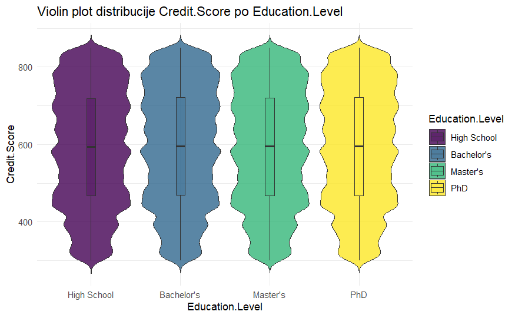

```r
ggplot(train, aes(x = Education.Level, y = Credit.Score, fill = Education.Level)) +
  geom_violin(trim = FALSE, alpha = 0.8) +
  geom_boxplot(width = 0.1, outlier.shape = NA, alpha = 0.3) +
  labs(title = "Violin plot distribucije Credit.Score po Education.Level", x = "Education.Level", y = "Credit.Score") +
  theme_minimal()
```

Statisticka analiza zavisnosti varijabli

```r
set.seed(123)
categories <- unique(train$Education.Level)
categories <- categories[!is.na(categories)]

shapiro_boot <- function(cat) {
  values <- na.omit(train$Credit.Score[train$Education.Level == cat])

  if (length(values) > 3) {
    p_values <- replicate(500, shapiro.test(sample(values, min(3000, length(values))))$p.value)
    p_mean <- mean(p_values)

    if (p_mean > 0.05) {
      sprintf("Varijabla Credit.Score po %s kategoriji ima normalnu raspodelu.", as.character(cat))
    } else {
      sprintf("Varijabla Credit.Score po %s kategoriji nema normalnu raspodelu.", as.character(cat))
    }
  }
  else {
    sprintf("Varijabla Credit.Score po %s kategoriji ima manje od 3 observacije.", as.character(cat))
  }
}

lapply(categories, shapiro_boot)
```

```
[[1]]
[1] "Varijabla Credit.Score po Bachelor's kategoriji nema normalnu raspodelu."

[[2]]
[1] "Varijabla Credit.Score po Master's kategoriji nema normalnu raspodelu."

[[3]]
[1] "Varijabla Credit.Score po High School kategoriji nema normalnu raspodelu."

[[4]]
[1] "Varijabla Credit.Score po PhD kategoriji nema normalnu raspodelu."
```

Kruskal-Wallis test radi statisticke provere distribucije po kategorijama:

```r
p_value <- kruskal_test(Credit.Score ~ Education.Level, data = train)$p

if (p_value > 0.05) {
  print("Nema statisticke razlike izmedju distribucija Credit.Score po kategorijama Education.Level atributa.")
} else {
  print("Postoji statisticka razlika izmedju distribucija Credit.Score po kategorijama Education.Level atributa.")
}
```

```
[1] "Postoji statisticka razlika izmedju distribucija Credit.Score po kategorijama Education.Level atributa."
```

Racunamo efekat Kruskal-Wallis testa kako bismo proverili:

```r
kruskal_effsize(Credit.Score ~ Education.Level, data = train)$effsize
```

```
Kruskal-Wallis chi-squared
               1.27774e-05
```

Iako je Kruskal-Wallis test ukazao na to da postoji statisticki znacajna razlika u raspodeli Credit.Score varijable u odnosu na nivoe Education.Level varijable, analizom efekta testa, kao i uporedjivanjem medijana i IQR-a, utvrdjujemo da je ova razlika minimalna i prakticno neprimenljiva.

### Credit.Score prema Previous.Claims

Posto su grupe koje imaju 7-9 zahteva veoma male, grupisacemo ih u jednu kategoriju “7+” radi testiranja.

```r
train$PreviousClaimsGrouped <- as.character(train$Previous.Claims)
train$PreviousClaimsGrouped[train$PreviousClaimsGrouped %in% c("7","8","9")] <- "7+"
train$PreviousClaimsGrouped <- factor(train$PreviousClaimsGrouped,
                                      levels = c("0","1","2","3","4","5","6","7+"))

table(train$PreviousClaimsGrouped, useNA="ifany")
```

```
     0      1      2      3      4      5      6     7+   <NA>
305433 300811 167661  49011  10668   2018    302     67 364029
```

Osnovni opis varijabli

```r
df_summary_feature <- train %>%
  group_by(PreviousClaimsGrouped) %>%
  summarise(
    Count = n(),
    Mean_Credit.Score = mean(Credit.Score, na.rm = TRUE),
    Median_Credit.Score = median(Credit.Score, na.rm = TRUE),
    Std_Credit.Score = sd(Credit.Score, na.rm = TRUE),
    IQR_Credit.Score = IQR(Credit.Score, na.rm = TRUE)
  )

print(df_summary_feature)
```

| PreviousClaimsGrouped | Count | Mean_Credit.Score | Median_Credit.Score | Std_Credit.Score | IQR_Credit.Score |
| --- | --- | --- | --- | --- | --- |
| 0 | 305433 | 589.1598 | 590 | 150.6636 | 254.00 |
| 1 | 300811 | 590.5450 | 591 | 150.4880 | 254.00 |
| 2 | 167661 | 606.9732 | 616 | 145.9906 | 240.00 |
| 3 | 49011 | 602.3973 | 607 | 147.5732 | 245.00 |
| 4 | 10668 | 595.3260 | 594 | 149.2440 | 246.75 |
| 5 | 2018 | 597.7655 | 600 | 149.4800 | 242.00 |
| 6 | 302 | 587.8855 | 583 | 148.1668 | 251.25 |
| 7+ | 67 | 580.6034 | 581 | 140.5925 | 208.50 |
| NA | 364029 | 590.2828 | 592 | 150.7133 | 254.00 |

Graficka reprezentacija varijabli

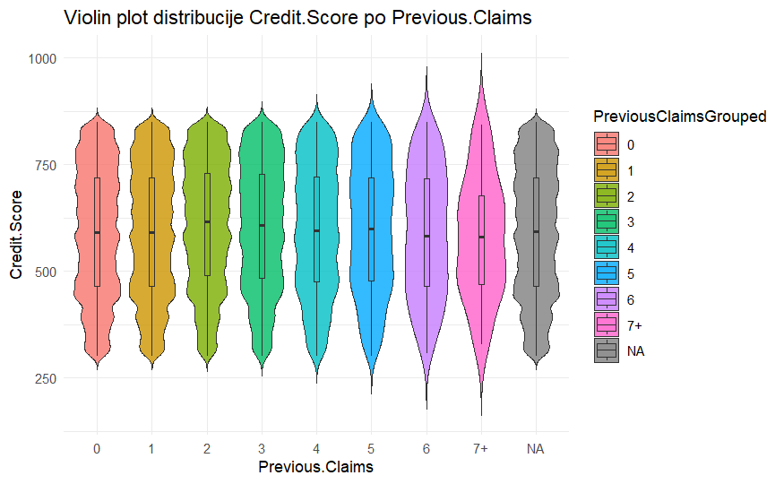

```r
ggplot(train, aes(x = PreviousClaimsGrouped, y = Credit.Score, fill = PreviousClaimsGrouped)) +
  geom_violin(trim = FALSE, alpha = 0.8) +
  geom_boxplot(width = 0.1, outlier.shape = NA, alpha = 0.3) +
  labs(title = "Violin plot distribucije Credit.Score po Previous.Claims", x = "Previous.Claims", y = "Credit.Score") +
  theme_minimal()
```

Statisticka analiza zavisnosti varijabli

```r
set.seed(123)
categories <- unique(train$PreviousClaimsGrouped)
categories <- categories[!is.na(categories)]

shapiro_boot <- function(cat) {
  values <- na.omit(train$Credit.Score[train$PreviousClaimsGrouped == cat])

  if (length(values) > 3) {
    p_values <- replicate(500, shapiro.test(sample(values, min(3000, length(values))))$p.value)
    p_mean <- mean(p_values)

    if (p_mean > 0.05) {
      sprintf("Varijabla Credit.Score po %s kategoriji ima normalnu raspodelu.", as.character(cat))
    } else {
      sprintf("Varijabla Credit.Score po %s kategoriji nema normalnu raspodelu.", as.character(cat))
    }
  }
  else {
    sprintf("Varijabla Credit.Score po %s kategoriji ima manje od 3 observacije.", as.character(cat))
  }
}

lapply(categories, shapiro_boot)
```

```
[[1]]
[1] "Varijabla Credit.Score po 2 kategoriji nema normalnu raspodelu."

[[2]]
[1] "Varijabla Credit.Score po 1 kategoriji nema normalnu raspodelu."

[[3]]
[1] "Varijabla Credit.Score po 0 kategoriji nema normalnu raspodelu."

[[4]]
[1] "Varijabla Credit.Score po 3 kategoriji nema normalnu raspodelu."

[[5]]
[1] "Varijabla Credit.Score po 4 kategoriji nema normalnu raspodelu."

[[6]]
[1] "Varijabla Credit.Score po 5 kategoriji nema normalnu raspodelu."

[[7]]
[1] "Varijabla Credit.Score po 6 kategoriji nema normalnu raspodelu."

[[8]]
[1] "Varijabla Credit.Score po 7+ kategoriji ima normalnu raspodelu."
```

Kruskal-Wallis test radi statisticke provere distribucije po kategorijama:

```r
p_value <- kruskal_test(Credit.Score ~ PreviousClaimsGrouped, data = train)$p

if (p_value > 0.05) {
  print("Nema statisticke razlike izmedju distribucija Credit.Score po kategorijama PreviousClaimsGrouped atributa.")
} else {
  print("Postoji statisticka razlika izmedju distribucija Credit.Score po kategorijama PreviousClaimsGrouped atributa.")
}
```

```
[1] "Postoji statisticka razlika izmedju distribucija Credit.Score po kategorijama PreviousClaimsGrouped atributa."
```

Racunamo efekat Kruskal-Wallis testa kako bismo proverili:

```r
kruskal_effsize(Credit.Score ~ PreviousClaimsGrouped, data = train)$effsize
```

```
Kruskal-Wallis chi-squared
                0.00134848
```

Odbacujemo kolonu PreviousClaimsGrouped

```r
train <- train %>%
  select(-PreviousClaimsGrouped)
```

Iako je Kruskal-Wallis test ukazao na to da postoji statisticki znacajna razlika u raspodeli Credit.Score varijable u odnosu na nivoe PreviousClaimsGrouped varijable, analizom efekta testa, kao i uporedjivanjem medijana i IQR-a, utvrdjujemo da je ova razlika minimalna i prakticno neprimenljiva.